### Comparison of the exponential distribution with the Central Limit Theorem

##### Jean-Michel Coeur, Statistical Inference Project 1, 3 April 2016

### 1. Overview

In this project we will investigate the exponential distribution in R and compare it with the Central Limit Theorem. This theorem states that the distribution of averages of iid variables (properly normalized) becomes that of a standard normal as the sample size increases.

To perform this analysis, we will simulate 1000 samples of averages of 40 exponential iid variables and perform the following steps:

1. Show the sample mean and compare it to the theoretical mean of the distribution.
2. Show how variable the sample is (via variance) and compare it to the theoretical variance of the distribution.
3. Show that the distribution is approximately normal.

This code book describes the analysis process and the results obtained at each step to reach to the conclusions.

### 2. Environment in use for the analysis

R libraries in use:

```r
# Required R packages to perform the analysis
require(ggplot2)    # Plotting system in use for the analysis
```

### 3. Data Simulation

From wikipedia: the exponential distribution is the probability distribution that describes the time between events in a Poisson process, in which events occur continuously and independently at a constant average rate lambda. This exponential distribution has two properties:

- a Mean `mu=1/lambda` and a Standard Deviation `sigma=1/lambda`.

To perform our analysis, we simulate the 1000 samples of 40 exponentials using the R function `rexp(nb, lamda)` with the following parameters:

- nb = number of samples * size of each sample: 1000 * 40
- lambda = 0.2.

```r
# To ensure reproduceability
set.seed(1769)
# Rate
lambda <- 0.2
# Theoretical Mean & Standard Deviation
t_mean <- t_sd <- 1/lambda # 5

# Samples size
n <- 40
# Number of simulations
nosim <- 1000

# We simulate 1000 samples of 40 exponentials
# Each row of the matrix represents 1 sample. We have 1000 rows.
mat <- matrix(rexp(nosim * n, lambda), ncol = n)

# We compute the mean of each sample and store it in a data frame as requested by ggplot
# for later display in this analysis
nosim_averages <- data.frame(xm = apply(mat, 1, mean))

# We compute the variance of each sample and store it in a data frame as requested by
# ggplot for later display in this analysis
ts_var <- function(x) { sd(x)^2 / n }
nosim_variances <- data.frame(xv = apply(mat, 1, ts_var))
```

The dataframe `nosim_averages` contains the averages of each of the 1000 samples of 40 exponentials.

The dataframe `nosim_variances` contains the variances of each of the 1000 samples of 40 exponentials

### 4. Sample Mean versus Theoretical Mean

The CLT states that averages are approximately normal, with distributions centered at the population mean with standard deviation equal to the standard error of the mean.

```r
# Compute the sample mean of the simulations
s_mean <- mean(nosim_averages$xm)
sd_ <- sd(nosim_averages$xm)
paste("Theoretical mean = ", t_mean); paste("Sample mean = ", round(s_mean, 3))
```

```
## [1] "Theoretical mean =  5"
```

```
## [1] "Sample mean =  5.025"
```

The sample mean is very close to the theoretical mean.

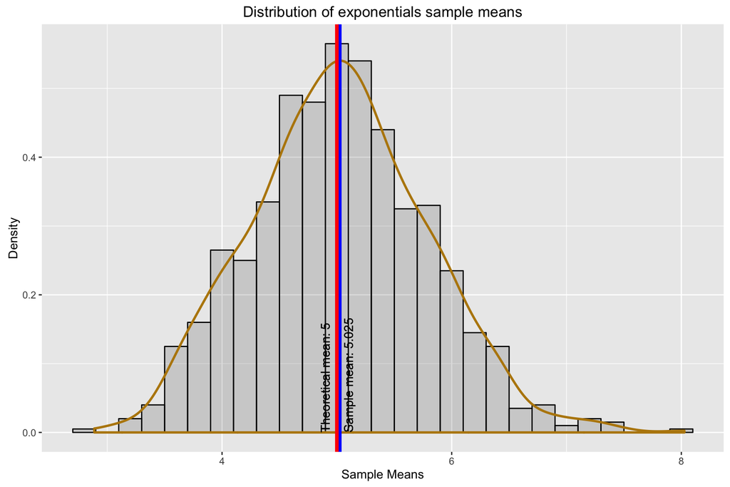

```r
# We plot the density
g <- ggplot(nosim_averages, aes(x = xm)) +
     geom_histogram(alpha = .20, binwidth=.2, colour = "black", aes(y = ..density..)) +
     ggtitle("Distribution of exponentials sample means") + xlab("Sample Means") +
     ylab("Density") + geom_density(colour="darkgoldenrod", size=1)

# We store the values and labels of means in a dataframe for display
d <- data.frame(mean = c(s_mean, t_mean), name = c("Sample mean", "Theoretical mean"))

# Add the vertical line and label: Thoeretical Mean
g <- g + geom_vline(xintercept = s_mean, size = 1.5, color = 'blue') +
     geom_text(data = d,
               mapping = aes(x=mean[1], y=0,
                             label=paste(name[1],round(s_mean, 3), sep = ": "),
                             angle = 90, vjust = 1.5, hjust = 0))

# Add the vertical line and label: Sample Mean
g <- g + geom_vline(xintercept = t_mean, size = 1.5, color = 'red') +
     geom_text(data = d,
              mapping = aes(x=mean[2], y=0, label=paste(name[2], t_mean, sep = ": "),
                        angle = 90, vjust = -0.8, hjust = 0))
g
```

The figure above represents the distribution of the averages of each sample.

- The red vertical line represents the value of the theoretital mean (population mean) `mu = 5`.
- The blue vertical line represents the value of the sample mean of the averages `ms = 5.025`

We can see that the distribution of the averages is centered at the population mean (mu = 5), as per the Central Limit Theorem.

### 5. Sample Variance versus Theoretical Variance

The theoretical variance of a sample is equal to variance divided by the size of the sample:

`var = sigma^2 / n`

The Central Limit Theorem states that averages are approximately normal, with distributions centered at the population mean with standard deviation equal to the standard error of the mean. Therefore, the mean of the sample variances should be close to the theoritical variance of a sample of size n.

```r
# Theoretical variance of sample of size n
t_var <- t_sd^2 / n
# Compute the sample variance from the mean of the distribution of 1000 variances
s_var <- mean(nosim_variances$xv)

paste("Theoretical variance = ", t_var); paste("Sample variance = ", round(s_var, 3))
```

```
## [1] "Theoretical variance =  0.625"
```

```
## [1] "Sample variance =  0.633"
```

Once again, as we increase the number of simulations (here nosim = 1000), the sample variance (s_var) is close to the theoretical variance (t_var).

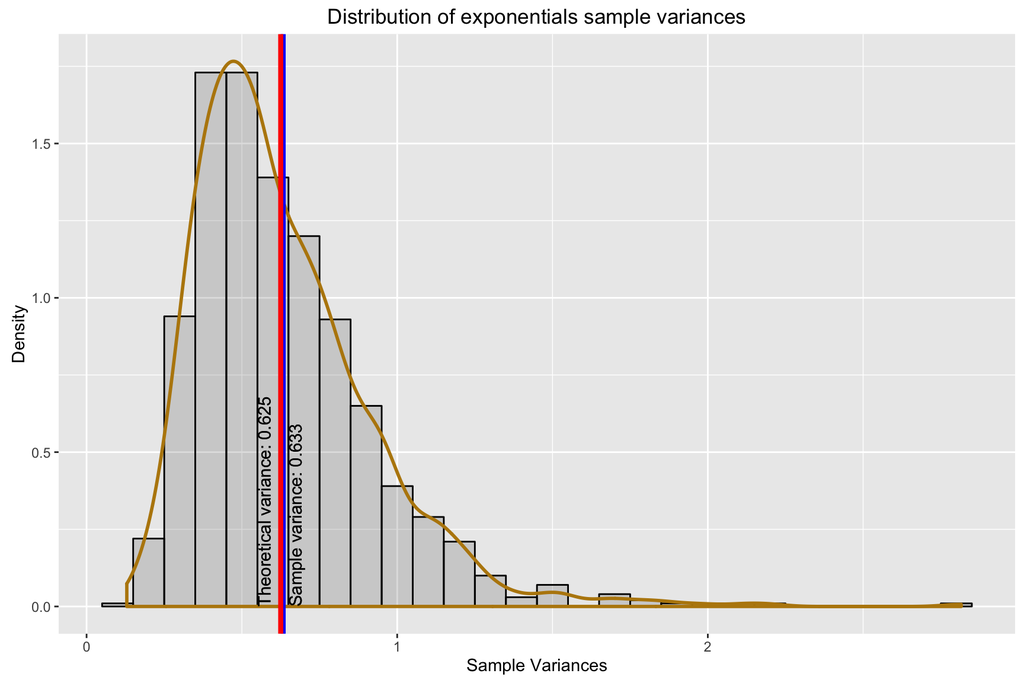

```r
# We plot the density
g <- ggplot(nosim_variances, aes(x = xv)) +
     geom_histogram(alpha = .20, binwidth=.1, colour = "black", aes(y = ..density..)) +
     ggtitle("Distribution of exponentials sample variances") + xlab("Sample Variances") +
     ylab("Density") + geom_density(colour="darkgoldenrod", size=1)

# We store the values and labels of means in a dataframe for display
d <- data.frame(var = c(s_var, t_var), name = c("Sample variance","Theoretical variance"))

# Add the vertical line and label: Thoeretical Mean
g <- g + geom_vline(xintercept = s_var, size = 1.5, color = 'blue') +
     geom_text(data = d,
               mapping = aes(x=var[1], y=0,
                             label=paste(name[1], round(s_var, 3), sep = ": "),
                             angle = 90, vjust = 1.5, hjust = 0))

# Add the vertical line and label: Sample Mean
g <- g + geom_vline(xintercept = t_var, size = 1.5, color = 'red') +
     geom_text(data = d,
               mapping = aes(x=var[2], y=0, label=paste(name[2], t_var, sep = ": "),
                             angle = 90, vjust = -0.8, hjust = 0))
g
```

The figure above represents the distribution of the variances of each sample.

- The red vertical line represents the value of the theoretital variance `v = 0.625`.
- The blue vertical line represents the value of the sample variance `vs = 0.633`

We verify that the sample variance (blue line) is close to the Theoretical variance (red line). The distribution of the sample variances is centered to the theoretical variance, as per the Central Limit Theorem.

### 6. Distribution

According to Central Limit Theorem, the density curve of the 1000 samples should follow approximately a bell curve whose mean is the mean of the exponential (mu = 5) and whose standard deviation is the standard error of the mean (sigma / sqrt(n)).

To verify this hypothesis, we plot:

- The density function of the distribution of the sample means (gold line),
- The normal distribution with mean mu = 5 and standard error of the mean se = sigma / sqrt(n) (black line)

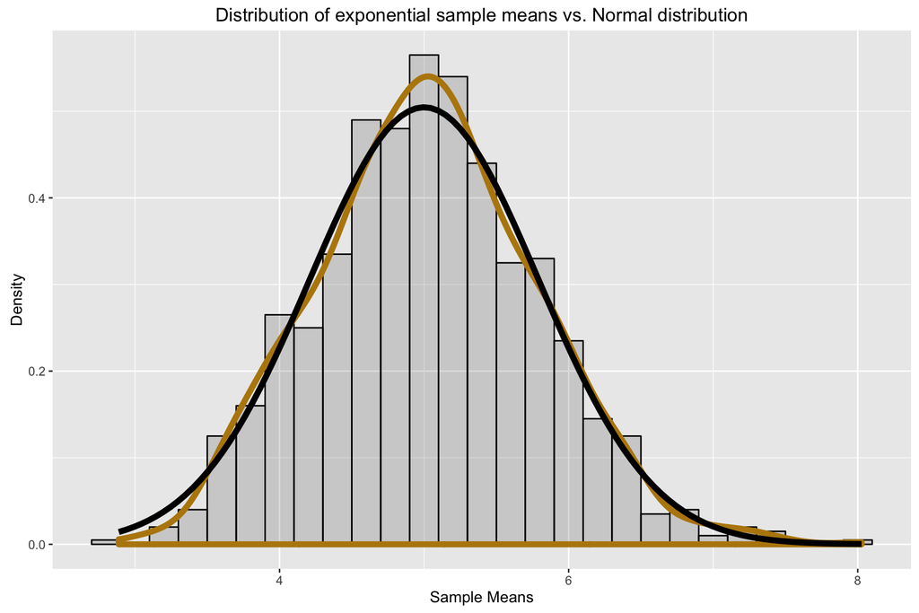

```r
# We plot the density
g <- ggplot(nosim_averages, aes(x = xm)) +
     geom_histogram(alpha = .20, binwidth=.2, colour = "black", aes(y = ..density..)) +
     ggtitle("Distribution of exponential sample means vs. Normal distribution") +
     xlab("Sample Means") + ylab("Density") +
     geom_density(colour = "darkgoldenrod", size = 2)

# We draw the normal distribution centered on mu = 5, with
# standard deviation = standard error of the mean
g <- g + stat_function(fun = dnorm, args = list(mean = t_mean,sd = t_sd/sqrt(n)),size = 2)
g
```

We verify that the density function of the sample means (gold line) is very close to the normal distribution (black line), which is stated by the Central Limtit Theorem. This is expected given the tests of the mean and variance successfully conducted previously.

```
                  ----------------- End of the analysis -----------------
```